# `riskyr` Data Formats

Hansjörg Neth, SPDS, uni.kn

2018 02 05

> The quest for certainty is the biggest obstacle to becoming risk savvy. (Gerd Gigerenzer)[^1]

A major challenge in mastering risk literacy is coping with inevitable uncertainty. Fortunately, uncertainty in the form of *risk* can be expressed in terms of probabilities and thus be measured and calculated — or “reckoned” — with (Gigerenzer, 2002). Nevertheless, probabilities are pretty big obstacles for everyone not trained as a statistician. As probabilities are notoriously difficult to communicate and understand, this vignette explains how probabilities can be defined and computed in terms of frequencies.

## Two Representational Formats

The problems addressed by `riskyr` and the scientific discussion surrounding them is framed in terms of two representational formats: *frequencies* are distinguished from *probabilities*. (See the user guide for background and references.)

`riskyr` reflects this division by distinguishing between the same two data types and hence provides objects that contain frequencies (specifically, a list called `freq`) and objects that contain probabilities (a list called `prob`). But before we explain their contents, it is important to realize that any such separation is an abstract and artificial one. It may make sense to distinguish frequencies from probabilities for conceptual and educational reasons, but both in theory and in reality both representations are intimately intertwined.

In the following, we will first consider frequencies and probabilities by themselves, but then show how both are related. As a sneak preview, the following network plot shows frequencies as its nodes and probabilities as the edges that link the nodes:

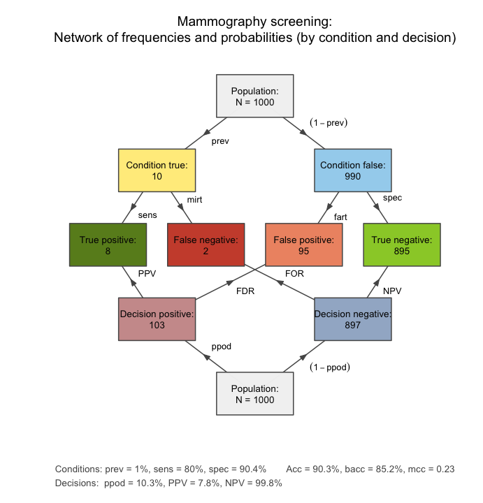

A network diagram that shows frequencies as nodes and probabilities as edges between nodes.

```r
library("riskyr") # load the "riskyr" package

plot_fnet(prev = .01, sens = .80, spec = NA, fart = .096,  # 3 essential probabilities
          N = 1000,       # 1 frequency
          area = "no",    # all boxes have the same size
          p.lbl = "nam",  # show probability names on edges
          title.lbl = "Mammography screening")
```

## Frequencies

For our purposes, frequencies simply are numbers that can be counted — either 0 or positive integers.[^2]

### Definitions

The following 11 frequencies are distinguished by `riskyr` and contained in `freq`:

| Nr. | Variable | Definition |
| --- | --- | --- |
| 1. | `N` | The number of cases (or individuals) in the population. |
| 2. | `cond.true` | The number of cases for which the condition is present (`TRUE`). |
| 3. | `cond.false` | The number of cases for which the condition is absent (`FALSE`). |
| 4. | `dec.pos` | The number of cases for which the decision is positive (`TRUE`). |
| 5. | `dec.neg` | The number of cases for which the decision is negative (`FALSE`). |
| 6. | `dec.cor` | The number of cases for which the decision is correct (correspondence of decision to condition). |
| 7. | `dec.err` | The number of cases for which the decision is erroneous (difference between decision and condition). |
| 8. | `hi` | The number of hits or true positives: condition present (`TRUE`) & decision positive (`TRUE`). |
| 9. | `mi` | The number of misses or false negatives: condition present (`TRUE`) & decision negative (`FALSE`). |
| 10. | `fa` | The number of false alarms or false positives: condition absent (`FALSE`) & decision positive (`TRUE`). |
| 11. | `cr` | The number of correct rejections or true negatives: condition absent (`FALSE`) & decision negative (`FALSE`). |

### Perspectives: Basic vs. combined frequencies

The frequencies contained in `freq` can be viewed from two perspectives:

- From the entire population to different parts or subsets (*top-down*):  
  Whereas `N` specifies the size of the entire population, the other 10 frequencies denote the number of individuals or cases in some subset. For instance, the frequency `dec.pos` denotes individuals for which the decision or diagnosis is positive. As this frequency is contained within the population, its numeric value must range from 0 to `N`.
- From four essential subgroups to various combinations of them (*bottom-up*):  
  As the four frequencies `hi`, `mi`, `fa`, and `cr` are not further split into subgroups, we can think of them as atomic elements or four *essential* frequencies. All other frequencies in `freq` are sums of various combinations of these four essential frequencies. This implies that the entire network of frequencies and probabilities (shown in the network diagram above) can be reconstructed from these four essential frequencies.

### Relationships among frequencies

The following relationships hold among the 11 frequencies:

1. The population size `N` can be split into several subgroups by classifying individuals by four different criteria:
   - 1. by condition
   - 2. by decision
   - 3. by the correspondence of decisions to conditions
   - 4. by the actual combination of condition and decision

Depending on the criterion used, the following relationships hold:

$$\begin{aligned}
\texttt{N} &= \texttt{cond.true} + \texttt{cond.false} & \textrm{(a)}\\
&= \texttt{dec.pos} + \texttt{dec.neg} & \textrm{(b)}\\
&= \texttt{dec.cor} + \texttt{dec.err} & \textrm{(c)}\\
&= \texttt{hi} + \texttt{mi} + \texttt{fa} + \texttt{cr} & \textrm{(d)}\\
\end{aligned}$$

Similarly, each of the subsets resulting from using the splits by condition, by decision, or by their correspondence, can also be expressed as a sum of two of the four essential frequencies. This results in three different ways of grouping the four essential frequencies:

1. by condition (corresponding to the two columns of the confusion matrix):

$$\begin{aligned}
\texttt{N} \ &= \ \texttt{cond.true} & +\ \ \ \ \ &\texttt{cond.false} & \textrm{(a)} \\
\ &= \ (\texttt{hi} + \texttt{mi}) & +\ \ \ \ \ &(\texttt{fa} + \texttt{cr}) \\
\end{aligned}$$

2. by decision (corresponding to the two rows of the confusion matrix):

$$\begin{aligned}
\texttt{N} \ &= \ \texttt{dec.pos} & +\ \ \ \ \ &\texttt{dec.neg} & \ \ \ \ \ \textrm{(b)} \\
\ &= \ (\texttt{hi} + \texttt{fa}) & +\ \ \ \ \ &(\texttt{mi} + \texttt{cr}) \\
\end{aligned}$$

3. by the correspondence of decisions to conditions (corresponding to the two diagonals of the confusion matrix):

$$\begin{aligned}
\texttt{N} \ &= \ \texttt{dec.cor} & +\ \ \ \ \ &\texttt{dec.err} & \ \ \ \ \textrm{(c)} \\
\ &= \ (\texttt{hi} + \texttt{cr}) & +\ \ \ \ \ &(\texttt{mi} + \texttt{fa}) \\
\end{aligned}$$

It may be tempting to refer to instances of `dec.cor` and `dec.err` as “true decisions” and “false decisions”. However, this would invite conceptual confusion, as “true decisions” actually include `cond.false` cases (`cr`) and “false decisions” actually include `cond.true` cases (`mi`).

## Probabilities

The notions of *probability* is as elusive as ubiquitous (see Hájek, 2012, for a solid exposition of its different concepts and interpretations). For our present purposes, probabilities are simply numbers between 0 and 1. These numbers are defined to reflect particular quantities and can be expressed as percentages or fractions of other numbers (frequencies or probabilities).

### Definitions

The following 10 probabilities are distinguished by `riskyr` and contained in `prob`:

| Nr. | Variable | Name | Definition |
| --- | --- | --- | --- |
| 1. | `prev` | prevalence | The probability of the *condition* being `TRUE`. |
| 2. | `sens` | sensitivity | The conditional probability of a *positive decision* provided that the *condition* is `TRUE`. |
| 3. | `mirt` | miss rate | The conditional probability of a *negative decision* provided that the *condition* is `TRUE`. |
| 4. | `spec` | specificity | The conditional probability of a *negative decision* provided that the *condition* is `FALSE`. |
| 5. | `fart` | false alarm rate | The conditional probability of a *positive decision* provided that the *condition* is `FALSE`. |
| 6. | `ppod` | proportion of positive decisions | The proportion (baseline probability or rate) of the *decision* being *positive* (but *not* necessarily `TRUE`). |
| 7. | `PPV` | positive predictive value | The conditional probability of the *condition* being `TRUE` provided that the *decision* is *positive*. |
| 8. | `FDR` | false detection rate | The conditional probability of the *condition* being `FALSE` provided that the *decision* is *positive*. |
| 9. | `NPV` | negative predictive value | The conditional probability of the *condition* being `FALSE` provided that the *decision* is *negative*. |
| 10. | `FOR` | false omission rate | The conditional probability of the *condition* being `TRUE` provided that the *decision* is *negative*. |

### Non-conditional vs. conditional probabilities

Note that there are only two *non-conditional* probabilities:

- The prevalence `prev` (1.) only depends on features of the *condition*.
- The proportion of positive decisions `ppod` (6.) only depends on features of the *decision*.

The other eight probabilities are *conditional* probabilities:

- Four conditional probabilities (2. to 5.) depend on the *condition*’s `prev` and features of the *decision*.
- Four conditional probabilities (7. to 10.) depend on the *decision*’s `ppod` and features of the *condition*.

### Relationships among probabilities

The following relationships hold among the conditional probabilities:

- The sensitivity `sens` and miss rate `mirt` are complements:

$$\texttt{sens} = 1 - \texttt{mirt}$$
- The specificity `spec` and false alarm rate `fart` are complements:

$$\texttt{spec} = 1 - \texttt{fart}$$
- The positive predictive value `PPV` and false detection rate `FDR` are complements:

$$\texttt{PPV} = 1 - \texttt{FDR}$$
- The negative predictive value `NPV` and false omission rate `FOR` are complements:

$$\texttt{NPV} = 1 - \texttt{FOR}$$

Although this is how the functions `comp_PPV` and `comp_NPV` compute the desired conditional probability, it is difficult to remember and think in these terms. Instead, we recommend thinking about and defining all conditional probabilities in terms of frequencies (see below).

## Probabilities as Ratios of Frequencies

The easiest way to think about, define, and compute the probabilities (contained in `prob`) are in terms of frequencies (contained in `freq`):

| Nr. | Variable | Name | Definition | as Frequencies |
| --- | --- | --- | --- | --- |
| 1. | `prev` | prevalence | The probability of the *condition* being `TRUE`. | `prev` = `cond.true`/`N` |
| 2. | `sens` | sensitivity | The conditional probability of a *positive decision* provided that the *condition* is `TRUE`. | `sens` = `hi`/`cond.true` |
| 3. | `mirt` | miss rate | The conditional probability of a *negative decision* provided that the *condition* is `TRUE`. | `mirt` = `mi`/`cond.true` |
| 4. | `spec` | specificity | The conditional probability of a *negative decision* provided that the *condition* is `FALSE`. | `spec` = `cr`/`cond.false` |
| 5. | `fart` | false alarm rate | The conditional probability of a *positive decision* provided that the *condition* is `FALSE`. | `fart` = `fa`/`cond.false` |
| 6. | `ppod` | proportion of positive decisions | The proportion (baseline probability or rate) of the *decision* being *positive* (but *not* necessarily `TRUE`). | `ppod` = `dec.pos`/`N` |
| 7. | `PPV` | positive predictive value | The conditional probability of the *condition* being `TRUE` provided that the *decision* is *positive*. | `PPV` = `hi`/`dec.pos` |
| 8. | `FDR` | false detection rate | The conditional probability of the *condition* being `FALSE` provided that the *decision* is *positive*. | `FDR` = `fa`/`dec.pos` |
| 9. | `NPV` | negative predictive value | The conditional probability of the *condition* being `FALSE` provided that the *decision* is *negative*. | `NPV` = `cr`/`dec.neg` |
| 10. | `FOR` | false omission rate | The conditional probability of the *condition* being `TRUE` provided that the *decision* is *negative*. | `FOR` = `mi`/`dec.neg` |

Note that the ratios of frequencies are straightforward consequences of the probabilities’ definitions:

1. The two unconditional probabilities (1. and 6.) are proportions of the entire population:
- `prev` = `cond.true`/`N`
- `ppod` = `dec.pos`/`N`
2. All conditional probabilities (2.–5. and 7.–10.) can be computed as a proportion of the reference group on which they are conditional. More specifically, if we schematically read each definition as “The conditional probability of $X$ provided that $Y$”, then the ratio of the corresponding frequencies is `X & Y`/`Y`. More explicitly,
- the ratio’s numerator is the frequency of the joint occurrence (i.e., both `X & Y`) being the case;
- the ratio’s denominator is the frequency of the condition (`Y`) being the case.

## Exercise

### An example

The following network diagram is based on the following inputs:

- a condition’s prevalence of 50% (`prev = .50`);
- a decision’s sensitivity of 80% (`sens = .80`);
- a decision’s specificity of 60% (`spec = .60`);
- a population size of 10 individuals (`N = 10`);

and illustrates the relationship between frequencies and probabilities:

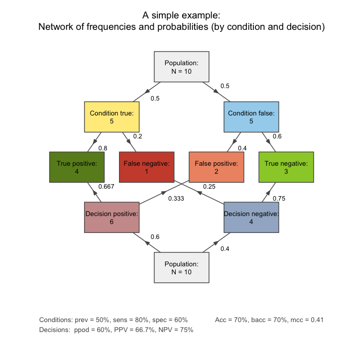

An example network diagram that shows how probabilities can be computed as ratios of frequencies.

```r
plot_fnet(prev = .50, sens = .80, spec = .60,  # 3 essential probabilities
          N = 10,         # 1 frequency
          area = "no",    # all boxes have the same size
          p.lbl = "num",  # show numeric probability values on edges
          title.lbl = "A simple example")
```

### Your tasks

1. Verify that the probabilities (shown as numeric values on the edges) match the ratios of the corresponding frequencies (shown in the boxes). What are the names of these probabilities?
2. What is the frequency of `dec.cor` and `dec.err` cases? Where do these cases appear in the diagram?

## References

- Gigerenzer, G. (2002). *Reckoning with risk: Learning to live with uncertainty*. London, UK: Penguin.
- Gigerenzer, G. (2014). *Risk savvy: How to make good decisions*. New York, NY: Penguin.
- Gigerenzer, G., & Hoffrage, U. (1999). Overcoming difficulties in Bayesian reasoning: A reply to Lewis and Keren (1999) and Mellers and McGraw (1999). *Psychological Review*, *106*, 425–430.
- Hájek, A (2012) [Interpretations of Probability](https://plato.stanford.edu/entries/probability-interpret/). In Edward N. Zalta (Ed.), *The Stanford Encyclopedia of Philosophy*. URL: https://plato.stanford.edu/entries/probability-interpret/ [2012 Archive](https://plato.stanford.edu/archives/win2012/entries/probability-interpret/)
- Hoffrage, U., Gigerenzer, G., Krauss, S., & Martignon, L. (2002). Representation facilitates reasoning: What natural frequencies are and what they are not. *Cognition*, *84*, 343–352.

## Contact

We appreciate your feedback, comments, or questions.

- Please report any `riskyr`-related issues at https://github.com/hneth/riskyr/issues.
- For general inquiries, please email us at contact.riskyr@gmail.com.

## All `riskyr` Vignettes

[figure not shown]

| Nr. | Vignette | Content |
| --- | --- | --- |
| 1. | User guide | Motivation and general instructions |
| 2. | Data formats | Data formats: Frequencies and probabilities |
| 3. | Confusion matrix | Confusion matrix and accuracy metrics |

[^1]: Gigerenzer, G. (2014). *Risk savvy: How to make good decisions*. New York, NY: Penguin. (p. 21).
[^2]: It seems plausible that the notion of a *frequency* is simpler than the notion of *probability*. Nevertheless, confusion is possible and typically causes serious scientific disputes. See Gigerenzer & Hoffrage, 1999, and Hoffrage et al., 2002, for different types of frequencies and the concept of “natural frequencies”.